# Práctica 2. Mapeo de secuencias cortas

Última actualización:

16 de mayo de 2026

# Preparación

Usaremos los programas siguientes:

- fastp (Chen et al. 2018). Si descargas el ejecutable en la carpeta actual, debes concederte el permiso de ejecución: `chmod u+x fastp`. Y además tendrás que invocarlo como `./fastp` para que Bash lo encuentre. Alternativamente, puedes copiarlo a una carpeta en tu `PATH`. Puedes consultar el `PATH` mediante `echo $PATH`.
- bwa (Li y Durbin 2009). Puedes descargar el código fuente con y compilarlo siguiendo estos pasos:

  ```
  git clone https://github.com/lh3/bwa.git
  cd bwa
  make
  ```

  Puedes copiar el ejecutable a cualquier carpeta en tu `PATH` o bien, invocarlo con su dirección completa cada vez que quieras ejecutarlo.
- [samtools](https://www.htslib.org/), junto con `htslib` y `bcftools` (Danecek et al. 2021). Los tres programas pueden descargarse del mismo enlace, donde hay instrucciones para instalar la versión más reciente. Para algunos sistemas operativos existen paquetes propios, que pueden instalarse así: `apt install samtools`.
- [freebayes](https://github.com/freebayes/freebayes/releases) (Garrison y Marth 2012).

# Objetivos

1. Control de calidad de lecturas cortas.
2. Mapeo de lecturas cortas a un genoma de referencia.
3. Identificación de variantes.

# Datos

A continuación descargamos un par de archivos FASTQ de la base de datos [ENA](https://www.ebi.ac.uk/ena/browser/home). Han sido seleccionados porque su tamaño (comprimidos) no supera los 100 MB. Son secuencias de la cepa Tsu4-125 de *Bradyrhizobium japonicum* (bacteria simbionte de la planta de soja). Proceden de la [Universidad de Tohoku](https://www.tohoku.ac.jp/en/) y forman parte de un [proyecto](https://www.ebi.ac.uk/ena/browser/view/PRJDB3261) en el que se secuenciaron 16 cepas más de *Bradyrhizobium*.

```bash
if [ ! -e DRR025089_1.fastq.gz ]; then
   # Con la opción "-o /dev/null" nos deshacemos de los mensajes.
   wget -o /dev/null \
        ftp://ftp.sra.ebi.ac.uk/vol1/fastq/DRR025/DRR025089/DRR025089_1.fastq.gz
fi
if [ ! -e DRR025089_2.fastq.gz ]; then
   wget -o /dev/null \
        ftp://ftp.sra.ebi.ac.uk/vol1/fastq/DRR025/DRR025089/DRR025089_2.fastq.gz
fi
```

**NotaDesafío**

Una vez descargados los archivos FASTQ, échales un vistazo desde la línea de órdenes. Puedes hacerlo con `zless`, una versión de `less` capaz de mostrar archivos comprimidos, o bien descomprimiendo los archvios con `gunzip`. Para no ocupar espacio de disco innecesariamente, puedes usar `gunzip -c DRR025089_1.fastq.gz | less -S`, que envía el contenido del archivo a la salida estándar (no a un archivo nuevo), de donde `less -S` lo lee, sin modificar nada en la carpeta. ¿Sabrías contar el número de líneas de cada archivo?

-Al usar el comando: `gunzip -c DRR025089_1.fastq.gz | less -S` en el terminal, se obtiene el siguiente resultado:

Muestra todo el resultado del archivo FASTQ en modo lectura (less); para salir del modo lectura y seguir usando el terminal, se pulsa la letra “Q”(quit).

¿Sabrías contar el número de líneas de cada archivo?

Para contar las líneas del archivo usamos el comando: “gunzip -c DRR025089_1.fastq.gz | wc -l”. Obteniendo un resultado de 1646728 líneas.

Necesitaremos también el genoma de referencia de `Bradyrhizobium japonicum`. Usaremos el de la cepa ACCC 15027 (hay otros).

```bash
# Con la opción "-o /dev/null" nos deshacemos de los mensajes,
# y con "-O referencia.fa" escogemos un nombre adecuado para el archivo.
if [ ! -e referencia.fa ]; then
   wget -o /dev/null -O referencia.fa \
        https://www.ebi.ac.uk/ena/browser/api/fasta/GCA_042137995.2
fi
```

-Archivo descargado correctamente.

**NotaPreguntas**

- ¿Crees que deberíamos guardar los archivos descargados en `../../data`?
- ¿Cómo podrías guardar los mensajes de `wget` en un archivo?
- ¿De cuántas secuencias diferentes se compone este genoma de referencia?

-Sí que se deberían guardar en data porque los archivos FASTQ son muy pesados (tamaño) y es recomendable guardarlos en una carpeta externa para no saturar la carpeta de trabajo.

-Para guardar los mensajes del wget, se debería sustituir la función /dev/null (que elimina los mensajes) por el nombre del archivo donde queremos guardar los mensajes (ejemplo, mensajes.txt).

-Para cuántas secuencias diferentes contiene el genoma de referencia se usa “grep -c”^>” referencia.fa” porque se sabe que en archivos FASTA cada nueva secuencia comienza con >. El resultado obtenido son 3 secuencias, que se pueden ver usando “grep”^>” referencia.fa”.

Las tres secuencias obtenidas serían:

>ENA|CP169752|CP169752.1 Bradyrhizobium japonicum strain ACCC 15027 chromosome, complete genome.

>ENA|CP169753|CP169753.1 Bradyrhizobium japonicum strain ACCC 15027 plasmid pA, complete sequence.

>ENA|CP169754|CP169754.2 Bradyrhizobium japonicum strain ACCC 15027 plasmid pB, complete sequence.

# Control de calidad

```bash
if [ ! -e fastp.html ]; then
   # Si "fastp" está en la carpeta actual y  no en el PATH, escribe "./fastp"
   # en lugar de "fastp".
   ../../bin/fastp -i DRR025089_1.fastq.gz \
         -o DRR025089_1_clean.fastq \
         -I DRR025089_2.fastq.gz \
         -O DRR025089_2_clean.fastq \
         --merge \
         --merged_out DRR025089_m_clean.fastq
fi
```

He obtenido varios archivos:

-**“fastp.html” y “fastp.json”**: Son los informes visuales del trabajo realizado por fastp en dos formatos (html y json). El programa fastp se encarga de limpiar las lecturas obtenidas de secuenciación, aplicando filtros de calidad y eliminando secuencias con errores o adaptadores artificiales.

-**“DRR025089_1_clean.fastq” y “DRR025089_2_clean.fastq”**: Son las lecturas que se han limpiado por separado.

-**“DRR025089_m_clean.fastq”**:Son las lecturas fusionadas (merged).

**NotaEjercicios**

1. Revisa la ayuda del programa ejecutando `fastp -h`, y asegúrate de entender al menos las opciones que hemos usado.

   Las opciones “-i” y “-I” referencian los archivos con las lecturas que serán trabajadas (hacia adelante y hacia atrás, respectivamente). “-O” y”-o” indican el nombre del archivo de salida. “merged” permite fusionar ambas lecturas si sus finales solapan creando una secuencia más larga.
2. Revisa el informe generado por `fastp` en el archivo `fastp.html` y redacta un pequeño resumen de las principales conclusiones que sacas.

En el informe se indica que se empleó una estrategia de secuenciación Paired-End con una longitud de lectura de 251 ciclos por cada extremo (esta es la configuración que se puso a la secuenciación). Inicialmente, se obtuvo una longitud media de lectura de 217-218 pb (no fueron 251 pb por factores como degradación química o eliminación de letras de baja calidad), mientras que el tamaño medio de los fragmentos de ADN fue de 199 pb, lo que indicó un solapamiento entre ambas lecturas (R1 y R2), pudiendo obtenerse un merged. Todos los resultados se encuentran representados gráficamente en el informe. En la primera gráfica, se puede ver la distribución de tamaños (histograma), donde la mayoría se agrupan en torno a las 200 pb (199 pb aprox).

En cuanto al control de calidad, se utilizó la escala Phred (Q20, Q30 y Q40). Tras el filtrado, incrementó el porcentaje de bases de alta calidad (Q30) hasta un 83.59%, siendo Q30 equivalente a un error por cada 1000 bases, lo que garantiza la fiabilidad de los siguientes análisis. El resultado se aprecia en los histogramas 5 y 6, donde se puede ver la distribución de la calidad de las bases antes y después del filtrado. Se aprecia como la mayoría se agrupan entorno a Q30-Q35 después del filtrado.

También se analizó el contenido de GC, que fue el esperado para *Bradyrhizobium* (62,76% obtenido, 63% esperado (buscado en Google)) confirmando la ausencia de contaminación. En las gráficas 7, 8 y 9 se puede ver la distribución del contenido de cada base para R1, R2 y merged. Finalmente, los resultados del filtrado muestran un éxito del 91,33% en las lecturas de manera que los datos de partida eran de buena calidad. Además, se realizó una corrección del 25,44% de las lecturas gracias al solapamiento (si en una pone A y en otra pone G, el programa corrige la base errónea basándose en la puntuación de calidad de cada letra).

3. Descarga un segundo conjunto de archivos FASTQ de la misma especie y repite el análisis de calidad con ellos. Puedes ver algunas opciones en este enlace. Es mejor no descargar archivos demasiado grandes.

```bash
if [ ! -e DRR025087_1.fastq.gz ]; then
   # Con la opción "-o /dev/null" nos deshacemos de los mensajes.
   wget -o /dev/null \
        ftp://ftp.sra.ebi.ac.uk/vol1/fastq/DRR025/DRR025087/DRR025087_1.fastq.gz
fi
if [ ! -e DRR025087_2.fastq.gz ]; then
   wget -o /dev/null \
        ftp://ftp.sra.ebi.ac.uk/vol1/fastq/DRR025/DRR025087/DRR025087_2.fastq.gz
fi
```

```bash
if [ ! -e fastp2.html ]; then
   # Si "fastp" está en la carpeta actual y  no en el PATH, escribe "./fastp"
   # en lugar de "fastp".
   ../../bin/fastp -i DRR025087_1.fastq.gz \
         -o DRR025087_1_clean.fastq \
         -I DRR025087_2.fastq.gz \
         -O DRR025087_2_clean.fastq \
         --merge \
         --merged_out DRR025087_m_clean.fastq
fi
```

```
Read1 before filtering:
total reads: 230183
total bases: 52591693
Q20 bases: 43550328(82.8084%)
Q30 bases: 38813111(73.8008%)
Q40 bases: 35(6.65504e-05%)

Read2 before filtering:
total reads: 230183
total bases: 52978349
Q20 bases: 39386878(74.3452%)
Q30 bases: 33672016(63.5581%)
Q40 bases: 30(5.66269e-05%)

Merged and filtered:
total reads: 106754
total bases: 24908719
Q20 bases: 22556206(90.5555%)
Q30 bases: 21163697(84.965%)
Q40 bases: 31(0.000124454%)

Filtering result:
reads passed filter: 410670
reads failed due to low quality: 49090
reads failed due to too many N: 606
reads failed due to too short: 0
reads failed due to adapter dimer: 0
reads with adapter trimmed: 29096
bases trimmed due to adapters: 709272
reads corrected by overlap analysis: 106250
bases corrected by overlap analysis: 331582

Duplication rate: 0.0460503%

Insert size peak (evaluated by paired-end reads): 202

Read pairs merged: 106754
% of original read pairs: 46.3779%
% in reads after filtering: 100%


JSON report: fastp.json
HTML report: fastp.html

../../bin/fastp -i DRR025087_1.fastq.gz -o DRR025087_1_clean.fastq -I DRR025087_2.fastq.gz -O DRR025087_2_clean.fastq --merge --merged_out DRR025087_m_clean.fastq
fastp v1.1.0, time used: 14 seconds
```

He escogido DRR025087. En el informe obtenido se indica que también se empleó una estrategia de secuenciación Paired-End con 251 ciclos. El tamaño medio del inserto fue de 202 pb (Histrograma 1), confirmando el solapamiento (se ha obtenido archivo merged).

Respecto al control de calidad, se ve que tras el filtrado se duplicó el valor de Q40 (pasó de 0,000062% a 0,000124%), y Q30 pasó de un 68,7% a un 84,96%. Esto indica que hubo un aumento de calidad tras el filtrado; Q40 implica que de cada 10000 bases hay 1 error (calidad excelente), y normalmente se encuentra en un porcentaje bajo porque es díficil alcanzar esa calidad. Es más habitual fijarse en el porcentaje del Q30 (1 error cada 1000 bases), ya que se encuentra en mayor proporción y puede estimar la calidad de la muestra de forma más realista.

# Mapeo

El objetivo de esta sección es alinear las lecturas cortas al genoma de referencia, mediante el programa `bwa`. El archivo final será un archivo BAM *ordenado*. Para obtener ese archivo es necesario generar algunos archivos auxiliares: primero, el índice del genoma de referencia, después los alineamientos en formato SAM (no comprimidos) y finalmente un archivo BAM, que es la versión comprimida del SAM (todavía no ordenado). La jerarquía de condiciones de ejecución siguiente permitirá borrar los archivos auxiliares, para ahorrar espacio, y no tener que generarlos de nuevo cada vez que compilemos este documento si el archivo final ya está presente en la carpeta de trabajo.

```bash
if [ ! -e DRR025089.bam ]; then

   if [ ! -e referencia.fa ]; then
      wget -O referencia.fa.gz ftp://ftp.ncbi.nlm.nih.gov/genomes/all/GCA/000/008/155/GCA_000008155.5_ASM815v5/GCA_000008155.5_ASM815v5_genomic.fna.gz

      gunzip referencia.fa.gz
   fi


   if [ ! -e DRR025089_unsorted.bam ]; then
      if [ ! -e DRR025089.sam ]; then
         if [ ! -e referencia.fa.bwt ]; then
            ../../bin/bwa/bwa index referencia.fa
         fi

         ../../bin/bwa/bwa mem -M -R '@RG\tID:DRR025089\tSM:SAMD00022947' \
                  -o DRR025089.sam \
                  referencia.fa \
                  DRR025089_1_clean.fastq \
                  DRR025089_2_clean.fastq \
                  1> bwa.log 2> bwa.err
      fi
      samtools view -b -o DRR025089_unsorted.bam DRR025089.sam
   fi

   samtools sort -o DRR025089.bam DRR025089_unsorted.bam
   samtools index DRR025089.bam


   if [ -f DRR025089.bam ]; then

      rm referencia.fa*
      rm DRR025089.sam
      rm DRR025089_unsorted.bam
   fi

fi
```

-He tenido que añadir la ruta relativa hasta bwa porque tengo el programa instalado en la carpeta /bin/bwa/.

**NotaDesafíos**

1. Entre las órdenes anteriores, añade la descarga del genoma de referencia en el lugar adecuado y bajo la condición adecuada para que pueda borrarse una vez se haya generado el alineamiento.

   Hecho.
2. En un bloque de órdenes nuevo, alinea también los pares de lecturas cortas que `fastp` había combinado (`DR025089_m_clean.fastq`).

```bash
if [ ! -e DRR025089_merged.bam ]; then

   if [ ! -e referencia.fa ]; then
      wget -O referencia.fa.gz ftp://ftp.ncbi.nlm.nih.gov/genomes/all/GCA/000/008/155/GCA_000008155.5_ASM815v5/GCA_000008155.5_ASM815v5_genomic.fna.gz
      gunzip referencia.fa.gz
   fi

   if [ ! -e DRR025089_merged_unsorted.bam ]; then
      if [ ! -e DRR025089_merged.sam ]; then
         if [ ! -e referencia.fa.bwt ]; then
            ../../bin/bwa/bwa index referencia.fa
         fi


         ../../bin/bwa/bwa mem -M -R '@RG\tID:DRR025089_m\tSM:SAMD00022947' \
                  -o DRR025089_merged.sam \
                  referencia.fa \
                  DRR025089_m_clean.fastq \
                  1> bwa_merged.log 2> bwa_merged.err
      fi

      samtools view -b -o DRR025089_merged_unsorted.bam DRR025089_merged.sam
   fi

   samtools sort -o DRR025089_merged.bam DRR025089_merged_unsorted.bam
   samtools index DRR025089_merged.bam

   if [ -f DRR025089_merged.bam ]; then
      rm referencia.fa*
      rm DRR025089_merged.sam
      rm DRR025089_merged_unsorted.bam
   fi
fi
```

Para este bloque he tenido que cambiar la entrada de bwa mem para que lea únicamente el archivo _m_clean.fastq, ya que al estar las lecturas fusionadas no existen parejas R1 y R2.

También he modificado los nombres de los archivos de salida a _merged.bam para evitar que el script sobrescriba o borre accidentalmente el alineamiento de las lecturas cortas anterior.

3. Lee la lista de funciones que te ofrece `samtools` al ejecutarlo sin ningún argumento. ¿Qué función usarías para combinar dos archivos BAM en uno?

Usaría la función “merge” para combinar dos archivos BAM en uno.

4. ¿Cuánto espacio de disco ocupan los archivos FASTQ, el genoma de referencia y su índice y el archivo SAM?

He usado el comando ls -lh para comprobar el tamaño de los archivos y he visto que los FASTQ limpios ocupan unos 73 MB cada uno. El archivo merged es un poco más grande y sube hasta los 106 MB. El archivo SAM es, con diferencia, el más pesado de todos con 183 MB, ya que guarda toda la información del alineamiento. Por último, el genoma de referencia y sus índices no aparecen en la lista porque el script los borra automáticamente al final para ahorrar espacio, pero su tamaño estimado es de unos 10 MB. Se ve claro que el SAM es el que más disco consume y por eso lo comprimimos a BAM y lo borramos.

5. Podíamos haber ahorrado algún paso aprovechando las *tuberías* de BASH:

```
bwa mem -M -R '@RG\tID:DRR025089\tSM:SAMD00022947' \
        referencia.fa DRR025089_1_clean.fastq DRR025089_2_clean.fastq | \
samtools view -u - | \
samtools sort - > DRR025089.bam
```

Este estilo tiene también la ventaja de ser más rápido. ¿Crees que hay algún inconveniente al usar las tuberías?

El principal inconveniente de usar tuberías es que, al no guardarse los archivos intermedios en el disco, perdemos la capacidad de revisar el archivo SAM o el BAM sin ordenar si necesitáramos comprobar algún detalle del alineamiento más adelante. Además, esto complica mucho la detección de errores; si algo falla en mitad de la tubería, es difícil identificar qué programa ha dado el problema porque los mensajes de error se mezclan y el flujo de datos no se detiene de forma clara.

Antes de proseguir, es importante comprobar el resultado del paso anterior. Podemos extraer algunas estadísticas del archivo BAM así:

```bash
if [ ! -e DRR025089.stats.txt ]; then
   samtools stats DRR025089.bam > DRR025089.stats.txt
fi

# Extraemos la sección sobre profundidad de cobertura
if [ ! -e stat.$i.txt ]; then
   grep ^COV DRR025089.stats.txt | cut -f 2- > COV.txt
fi
```

Ahora podemos importar los datos de cobertura a una sesión de R y representarlos gráficamente:

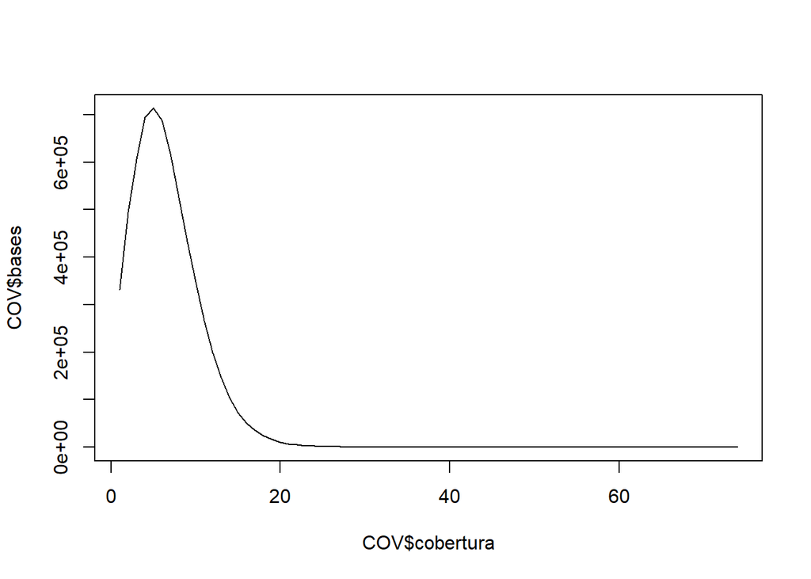

```r
COV <- read.table('COV.txt',
                  col.names = c('intervalo', 'cobertura', 'bases'))
plot(COV$cobertura, COV$bases, type = 'l')
```

**NotaDesafíos**

1. La distribución de cobertura tiene una cola larga. ¿Puedes centrar la representación gráfica entre 0 y 20? Pista: usa la opción `xlim` de `plot()`.

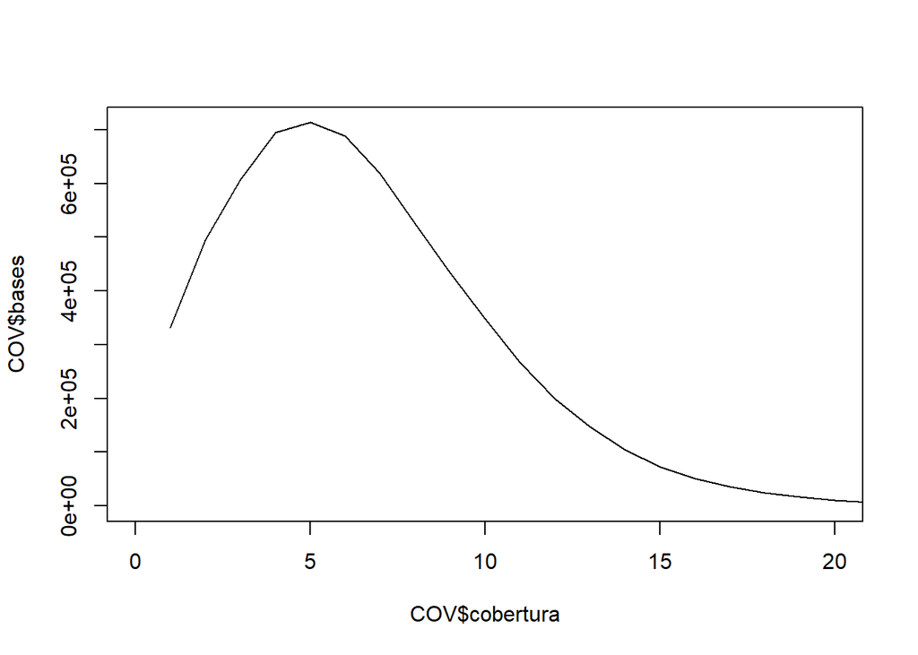

```r
plot(COV$cobertura, COV$bases, type = 'l', xlim = c(0, 20))
```

2. ¿Qué otras estadísticas crees que vale la pena revisar?

Además de la cobertura, creo que sería muy importante revisar el porcentaje de lecturas mapeadas, para confirmar que la mayoría de nuestras secuencias pertenecen realmente al genoma de referencia y no son contaminación. También valdría la pena mirar la calidad del mapeo (MAPQ), para asegurarnos de que las lecturas se han posicionado de forma única y fiable, y el porcentaje de duplicados, ya que un exceso de copias idénticas por la PCR podría sesgar los resultados finales. Por último, calcularía la cobertura media para tener un valor numérico que resuma la calidad del experimento.

3. El genoma de referencia incluye dos plásmidos. ¿La cepa secuenciada los tiene?

```bash
samtools idxstats DRR025089.bam
```

```
ENA|CP169752|CP169752.1 9460647 230509  2965
ENA|CP169753|CP169753.1 440193  965 89
ENA|CP169754|CP169754.2 122010  112 3
*   0   0   56574
```

Tras ejecutar samtools idxstats, he observado que la inmensa mayoría de las lecturas (230.509) han mapeado contra el cromosoma principal (CP169752.1). En cambio, los dos plásmidos presentan una cantidad de lecturas mapeadas insignificante (965 y 112 respectivamente) en comparación con su longitud. Si la cepa realmente tuviera estos plásmidos, esperaríamos una densidad de lecturas similar a la del cromosoma. Por tanto, los resultados indican que la cepa secuenciada no posee estos dos plásmidos de la referencia.

4. Visualiza los alineamientos en el terminal con la orden siguiente:

He cometido un error; al pedir en uno de los ejercicios que se eliminaran los archivos extra para ahorrar espacio, también incluí el referencia.fa porque no lo consideraba importante. Por ello, vuelvo a descargarlo:

```bash
wget -O referencia.fa "https://eutils.ncbi.nlm.nih.gov/entrez/eutils/efetch.fcgi?db=nuccore&id=CP169752.1&rettype=fasta"
```

[output not shown]

[output cut: 142 more lines]

[output not shown]

Al intentar descargar de nuevo el archivo referencia.fa usando el enlace wget del bloque original me saltaba un error 404. Tras probar varias veces y ver que el error era el mismo, traté de buscar la URL manualmente entrando en el NCBI, y al entrar salía un mensaje donde se informaba de un cambio de plataforma de “Assembly” a “NCBI Datasets”. Sin embargo, tampoco conseguí encontrar el archivo en la nueva plataforma de datasets ya que daba error. Por ello, he recurrido al uso de Gemini, que ha planteado como solución conectarse directamente a la API de nucleótidos de la base de datos central (E-utils) usando el identificador directo del cromosoma (CP169752.1) para saltar los buscadores caídos.

```bash
head -n 5 referencia.fa
```

```
>CP169752.1 Bradyrhizobium japonicum strain ACCC 15027 chromosome, complete genome
ATGAACACATCGGAACAGGATCGCTGGTCACGCGTGAAGAGCCGGCTGCGCTCGAATGTAGGCGAAGACG
TCTATACGAGCTGGTTTGCCCGCATGGATCTGGAAGGCGTGCAGGAGGAGAGCGTGCGGCTCTCGGTGCC
GACCCGCTTCCTGAAGAGCTGGATTCAGGCGCATTATGCCGAGCGCGTGCTGTCGTGCTGGCAGGCCGAG
GCGCCGGAGGTGCATCGCATCGATCTCACCGTTCGCTCCGCGGTGCGCCCGGTCGTGCAGCAGAAGGAGA
```

Al ejecutar el bloque de la IA he conseguido un archivo de referencia.fa de 9.6 MB, que es el tamaño correcto para este cromosoma (además he comprobado que comenzara correctamente usando “head -n 5”). Sin embargo, al hacer el tview aparecía un error con el nombre: “None of the BAM sequence names present in the fasta file”. Esto ocurre porque nuestro archivo BAM utiliza la nomenclatura del repositorio europeo (ENA), donde el cromosoma se llama “>ENA|CP169752|CP169752.1”, mientras que el FASTA que nos acabamos de bajar del NCBI lo nombra simplemente como “>CP169752.1”. Como los nombres no coinciden exactamente, el programa no arranca. La solución planteada por Gemini ha sido usar el comando sed para editar la cabecera del FASTA y ponerle el nombre largo que busca el BAM, para luego volver a indexarlo.

```bash
# 1. Reemplazamos el nombre corto por el nombre largo que busca el BAM
sed -i 's/>CP169752.1/>ENA|CP169752|CP169752.1/' referencia.fa

# 2. Como hemos modificado el archivo, tenemos que volver a indexarlo obligatoriamente
rm -f referencia.fa.fai
samtools faidx referencia.fa
```

```bash
samtools tview DRR025089.bam referencia.fa
```

Como samtools tview es un programa interactivo de consola, el chunk de RStudio se queda corriendo todo el rato y con la rueda de carga dando vueltas. Una vez que ya he visto el alineamiento y he terminado con el ejercicio, tengo que pulsar manualmente el botón rojo de “Stop” en RStudio para cerrar el programa; si no lo hago, el notebook se quedaría colgado pensando infinitamente y luego no me dejaría compilar el documento final de la práctica.

# Identificación de variantes

```bash
samtools faidx referencia.fa
```

```bash
../../bin/freebayes -p 1 -f referencia.fa DRR025089.bam > DRR025089.vcf
```

Al lanzar el comando original, el proceso fallaba al instante dejando el archivo VCF completamente vacío (0 bytes). Tras revisar las carpetas de la práctica y consultar con Gemini, descubrimos que el script buscaba el ejecutable con el nombre corto freebayes, pero en mi servidor el programa se guardó tras la descarga con su nombre largo original (freebayes-1.3.10-linux-amd64-static). Al no coincidir el nombre, el sistema no lo encontraba. La solución fue mover el ejecutable a la carpeta /bin de la práctica, renombrarlo como freebayes a secas y darle permisos de ejecución con chmod +x. Tras esto, el programa arrancó y estuvo procesando los datos durante varios minutos, generando un archivo VCF que llegó a pesar 112 MB.

Sin embargo, justo al final de la ejecución, el programa se detuvo mostrando el siguiente mensaje de advertencia: unable to find FASTA index entry for ‘ENA|CP169753|CP169753.1’.

El análisis de variantes cosniste en comparar las lecturas secuenciadas de nuestra muestra frente a un genoma de referencia para identificar mutaciones. Al realizar este proceso con freebayes, el programa genera un archivo VCF que es como un mapa donde cada línea representa una coordenada del genoma bacteriano que presenta un cambio genético respecto al molde original (genoma referencia).

Al revisar el archivo de 112 MB que me ha salido, veo que cada fila detalla el cromosoma y la posición exacta de la mutación, enseñando el nucleótido original en la columna REF y el mutado en ALT. He estado buscando en la documentación oficial de freebayes en GitHub (Garrison, E. y Marth, G., 2012) y ahí explican que este programa funciona analizando los haplotipos directamente de las lecturas alineadas para calcular la probabilidad de que cada variante sea real. Esto se nota en mi archivo en el parámetro QUAL, que da una puntuación muy alta que sirve para descartar que sea un simple fallo de secuenciación, y también en la columna INFO, donde el manual de la web indica que el programa es capaz de clasificar si el cambio es un SNP normal de una letra, un indel o un bloque “complex” de varias mutaciones juntas. La última columna es el resultado final de la muestra para esa mutación. Eso confirma que la bacteria es mutante pura (GT=1) en esa posición y enseña los datos reales de cuántas lecturas ha usado el programa (DP y AO) para estar totalmente seguro de que la mutación existe y no es un error de la máquina.

## Bibliografía

Chen, Shifu, Yanqing Zhou, Yaru Chen, y Jia Gu. 2018. «fastp: an ultra-fast all-in-one FASTQ preprocessor». *Bioinformatics* 34 (17): i884-90. https://doi.org/10.1093/bioinformatics/bty560.

Danecek, Petr, James K Bonfield, Jennifer Liddle, John Marshall, Valeriu Ohan, Martin O Pollard, Andrew Whitwham, et al. 2021. «Twelve years of SAMtools and BCFtools». *GigaScience* 10 (2). https://doi.org/10.1093/gigascience/giab008.

Garrison, E., y G. Marth. 2012. «Haplotype-based variant detection from short-read sequencing». https://arxiv.org/abs/1207.3907.

Li, Heng, y Richard Durbin. 2009. «Fast and accurate short read alignment with Burrows–Wheeler transform». *Bioinformatics* 25 (14): 1754-60. https://doi.org/10.1093/bioinformatics/btp324.